# Final EDA Notebook

Amy Chen

2023-12-05

# Introduction and Research Overview:

For our exploratory data analysis project, we wanted to examine the impact of undergraduate college majors on future employment opportunities and earnings. College students widely believe that their undergraduate major has implications on their future career opportunities and lifelong earnings. A multitude of factors ultimately contribute to their decision process, such as personal aptitudes, aspirations, and financial motives. For example, students who prioritize high salaries may sacrifice genuine academic interests to pursue a degree in a more lucrative field.

Cultural factors beyond students’ control also assign different values to specific skills and industries. Science, technology, engineering, and math (STEM) are subjects associated with high levels of prestige and intelligence due to their technical nature and high demand in the U.S. job market. Other disciplines that focus on transferable skills, such as writing, critical thinking, or creativity, tend to receive less recognition as it is believed that these skills can be more easily obtained. Furthermore, emotional labor associated with femininity, such as teaching, nursing, or counseling, tend to be undervalued in our society due to persistent gender discrimination. Therefore, women experience multiple forms of discrimination and inequality that shape their educational and career trajectories. These cultural factors can strongly influence students’ decision-making in terms of their undergraduate major and occupational pursuits.

To determine whether or not undergraduate college majors affect career opportunities and financial outlooks of graduating students, we searched for a nationally representative dataset that reported information on college majors, post-grad salaries, and employment rates. The American Community Survey (ACS) Public Use Microdata Series (PUMS) from 2010 to 2012 collects information on social, economic, and demographic characteristics from its participants, which includes the variables that our research requires. The U.S. Census Bureau conducts this particular survey across households from all U.S. counties in a randomized manner. This ensures that the methods of data collection is nationally representative and unbiased.

The specific dataset that we used for data analysis has been filtered and structured by FiveThirtyEight, an online journalism organization that uses empirical evidence and transparent data sources in its publications. FiveThirtyEight has previously conducted research studies examining the relationship between college majors and economic outcomes. Therefore, they have intentionally selected variables relevant to recent graduates in their filtered version of the ACS survey.. Through our analysis, we hope to transparently inform students about their future job prospects and salary expectations available based on their college major. By including gender, we aim to illuminate any inequalities between men and women in terms of industry, pay, and employment. We also want to acknowledge that earnings and employment are not the only measures of career or financial success. However, for a large majority of the working population, these variables can significantly impact one’s quality of life.

```r
recent_grads <- read.csv("recent-grads.csv")
```

# Brief Overview of Data

We used the summary function to get a glimpse into our dataset (recent_grads) and the types of variables available. As seen below, the summary function produces a brief overview of each variable and its extremities. Notable variables that appealed to our research question include: Major, Major_cateogry (general field of study), Total (count of graduates), Employed (count of employed graduates), Median (salary), Full_time (count of graduates working full-time), and ShareWomen (proportion of women in each major). We will further investigate these variables to produce insights about the popularity of majors, job opportunities on the market, salary outlooks, and gender distribution.

```r
summary(recent_grads)
```

```
##       Rank       Major_code      Major               Total
##  Min.   :  1   Min.   :1100   Length:173         Min.   :   124
##  1st Qu.: 44   1st Qu.:2403   Class :character   1st Qu.:  4550
##  Median : 87   Median :3608   Mode  :character   Median : 15104
##  Mean   : 87   Mean   :3880                      Mean   : 39370
##  3rd Qu.:130   3rd Qu.:5503                      3rd Qu.: 38910
##  Max.   :173   Max.   :6403                      Max.   :393735
##                                                  NA's   :1
##       Men             Women        Major_category       ShareWomen
##  Min.   :   119   Min.   :     0   Length:173         Min.   :0.0000
##  1st Qu.:  2178   1st Qu.:  1778   Class :character   1st Qu.:0.3360
##  Median :  5434   Median :  8386   Mode  :character   Median :0.5340
##  Mean   : 16723   Mean   : 22647                      Mean   :0.5222
##  3rd Qu.: 14631   3rd Qu.: 22554                      3rd Qu.:0.7033
##  Max.   :173809   Max.   :307087                      Max.   :0.9690
##  NA's   :1        NA's   :1                           NA's   :1
##   Sample_size        Employed        Full_time        Part_time
##  Min.   :   2.0   Min.   :     0   Min.   :   111   Min.   :     0
##  1st Qu.:  39.0   1st Qu.:  3608   1st Qu.:  3154   1st Qu.:  1030
##  Median : 130.0   Median : 11797   Median : 10048   Median :  3299
##  Mean   : 356.1   Mean   : 31193   Mean   : 26029   Mean   :  8832
##  3rd Qu.: 338.0   3rd Qu.: 31433   3rd Qu.: 25147   3rd Qu.:  9948
##  Max.   :4212.0   Max.   :307933   Max.   :251540   Max.   :115172
##
##  Full_time_year_round   Unemployed    Unemployment_rate     Median
##  Min.   :   111       Min.   :    0   Min.   :0.00000   Min.   : 22000
##  1st Qu.:  2453       1st Qu.:  304   1st Qu.:0.05031   1st Qu.: 33000
##  Median :  7413       Median :  893   Median :0.06796   Median : 36000
##  Mean   : 19694       Mean   : 2416   Mean   :0.06819   Mean   : 40151
##  3rd Qu.: 16891       3rd Qu.: 2393   3rd Qu.:0.08756   3rd Qu.: 45000
##  Max.   :199897       Max.   :28169   Max.   :0.17723   Max.   :110000
##
##      P25th           P75th         College_jobs    Non_college_jobs
##  Min.   :18500   Min.   : 22000   Min.   :     0   Min.   :     0
##  1st Qu.:24000   1st Qu.: 42000   1st Qu.:  1675   1st Qu.:  1591
##  Median :27000   Median : 47000   Median :  4390   Median :  4595
##  Mean   :29501   Mean   : 51494   Mean   : 12323   Mean   : 13284
##  3rd Qu.:33000   3rd Qu.: 60000   3rd Qu.: 14444   3rd Qu.: 11783
##  Max.   :95000   Max.   :125000   Max.   :151643   Max.   :148395
##
##  Low_wage_jobs
##  Min.   :    0
##  1st Qu.:  340
##  Median : 1231
##  Mean   : 3859
##  3rd Qu.: 3466
##  Max.   :48207
##
```

# Checking for Missing Values

```r
na_counts <- sapply(recent_grads, function(x) sum(is.na(x)))
print(na_counts)
```

```
##                 Rank           Major_code                Major
##                    0                    0                    0
##                Total                  Men                Women
##                    1                    1                    1
##       Major_category           ShareWomen          Sample_size
##                    0                    1                    0
##             Employed            Full_time            Part_time
##                    0                    0                    0
## Full_time_year_round           Unemployed    Unemployment_rate
##                    0                    0                    0
##               Median                P25th                P75th
##                    0                    0                    0
##         College_jobs     Non_college_jobs        Low_wage_jobs
##                    0                    0                    0
```

# Number of Specializations in Each Major Category:

The graph below shows the distribution of specializations within each major category. Engineering is the most diverse major, encompassing nearly 30 different disciplines. There is a noticeably large gap between the number of fields within engineering and all other major categories. It is loosely followed by education and the liberal arts. At the opposite end of the spectrum, interdisciplinary majors have the least variety of specializations. Interdisciplinary studies typically combine two divergent academic disciplines into one major based on the student’s interests. However, it is not the only major that can do so. Other majors may teach interdisciplinary content but still be categorized differently due to varying university standards. Interdisciplinary majors, as defined in this dataset, specifically involve student-created majors that do not fall into an established academic department. The lack of variety in interdisciplinary studies aligns with our expectations as student-created majors are a relatively new concept in higher education, and many universities have not yet established programs for this particular major.

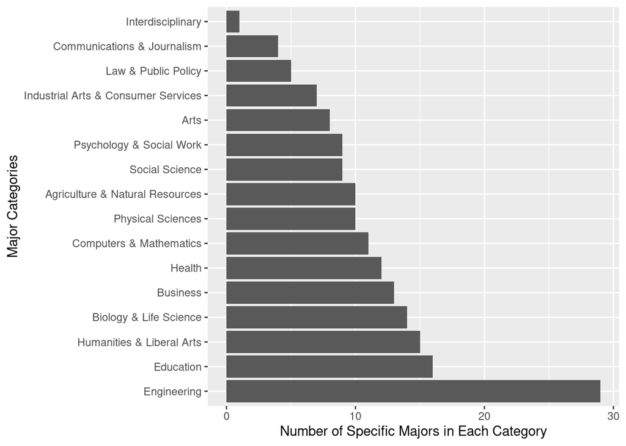

```r
recent_grads$Major_category <- factor(recent_grads$Major_category, levels = unique(recent_grads$Major_category))

ggplot(recent_grads, aes(x = reorder(Major_category, -table(Major_category)[Major_category]))) +
  geom_bar() +
  xlab("Major Categories") +
  ylab("Number of Specific Majors in Each Category") +
  coord_flip()
```